# The most valued data science skills!

Team 3  
03/30/2017

### Introduction

As part of the course curriculum:

- This project exposes the entire team to a broad array of skills including communications, team building, goal setting, task identification and delegation.
- In a nutshell, this project can be summarized as building project management skills with virtual teams.

### Team 3

CUNY MSDA

DATA 607

| Name | Team | Email |
| --- | --- | --- |
| Pavan Akula | Team 3 | akulapavan@hotmail.com |
| Ambra Baboni Alexander | Team 3 | ambra8due@hotmail.com |
| Thomas Detzel | Team 3 | tomdetz@gmail.com |
| Dilip Ganesan | Team 3 | dilipgan@gmail.com |
| Kyle Gilde | Team 3 | kylegilde@gmail.com |
| Raghunathan Rammnath | Team 3 | raghu74us@gmail.com |
| Duubar Villalobos Jimenez | Team 3 | mydvtech@gmail.com |

### Overview

[figure not shown]

We have gathered our data from:

https://www.paysa.com/

“Get paid what you deserve!”

### Project - Data Science Skills

Sample of job listings for “Data Science”.

[figure not shown]

### Project - Data Science Skills

“Data Science” postings with desired listed skills.

[figure not shown]

### Project - Data Science Skills

Sample of our Paysa.txt file.

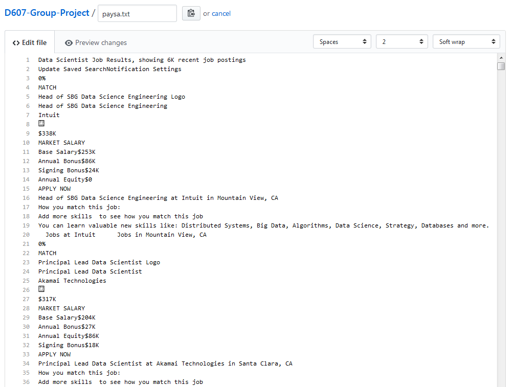

### Project - Data Science Skills

Tidy table

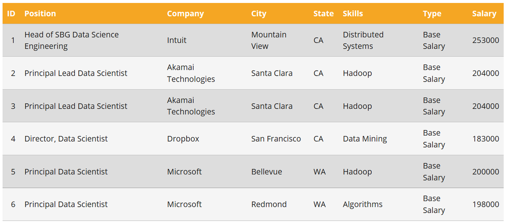

### Project - Data Science Skills

**Top 10** most desired skills by Employers.

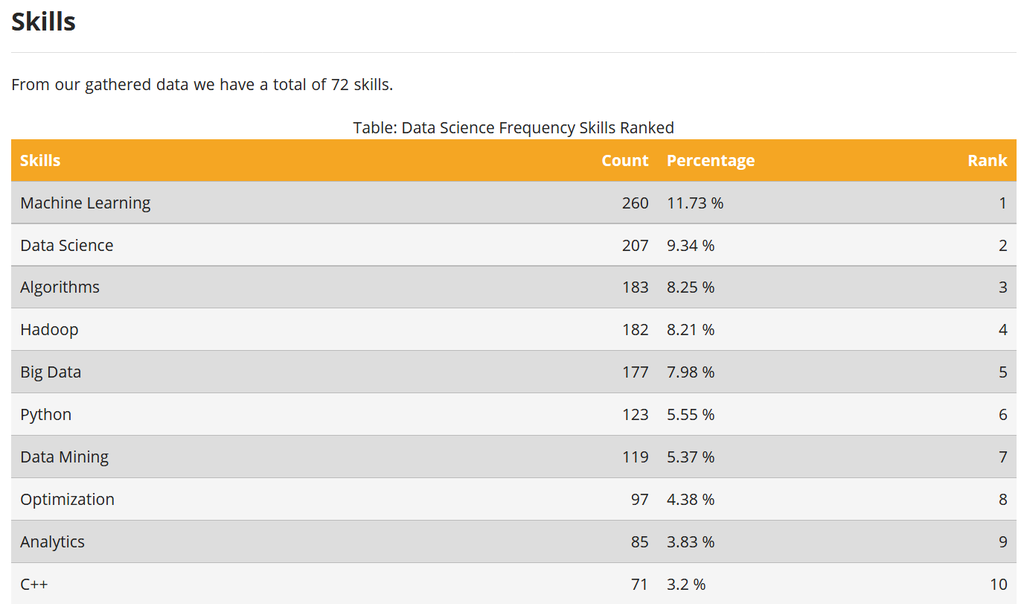

### Project - Data Science Skills

**Top 10** most desired skills by Employers.

[interactive chart not shown]

### Project - Data Science Skills

The **MOST** desired skill by employers

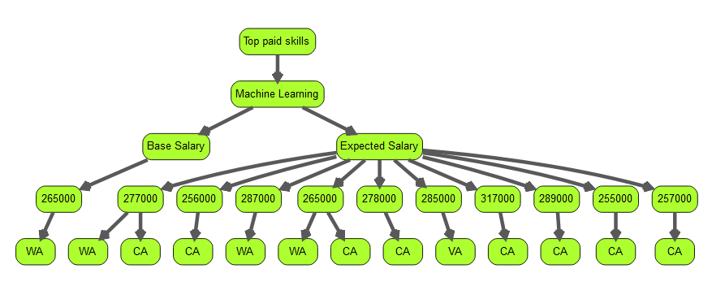

### Project - Data Science Skills

Top 10 **offered** salaries

[interactive chart not shown]

### Project - Data Science Skills

Top 10 **signing** bonus

[interactive chart not shown]

### Project - Data Science Skills

Top 10 **annual** salaries

[interactive chart not shown]

### Project - Data Science Skills

Top 10 **base** salaries

[interactive chart not shown]

### Project - Data Science Skills

Top ranked skills vs highest paid

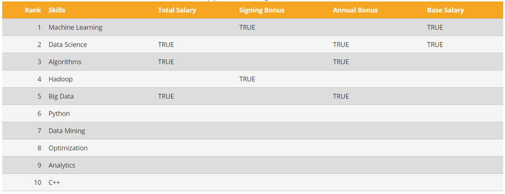

### Project - Data Science Skills

[interactive chart not shown]

### Project - Data Science Skills

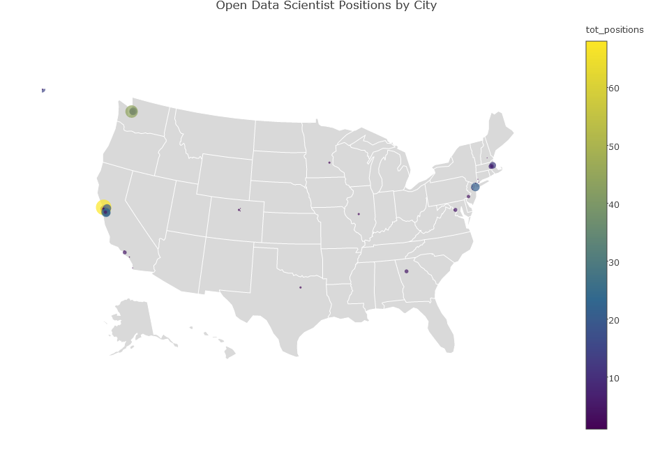

### Project - Data Science Skills

Highest-Valued Skills Measured by Mean Compensation

- Some of the highest-valued skills are not the most common skills. They include Strategy, Leadership, Management and Data Science, a catch-all. ETL - for Extract, Transfer and Load - is a critical area of data warehousing.

### Project - Data Science Skills

Highest-Valued Skills Measured by Mean Compensation

- This part of the analysis looks at the value of skills based on what employers pay rather the frequency of skills in a job posting. To do this, we compute a mean value for each skill across the database.

### Project - Data Science Skills

Highest-Valued Skills Measured by Mean Compensation

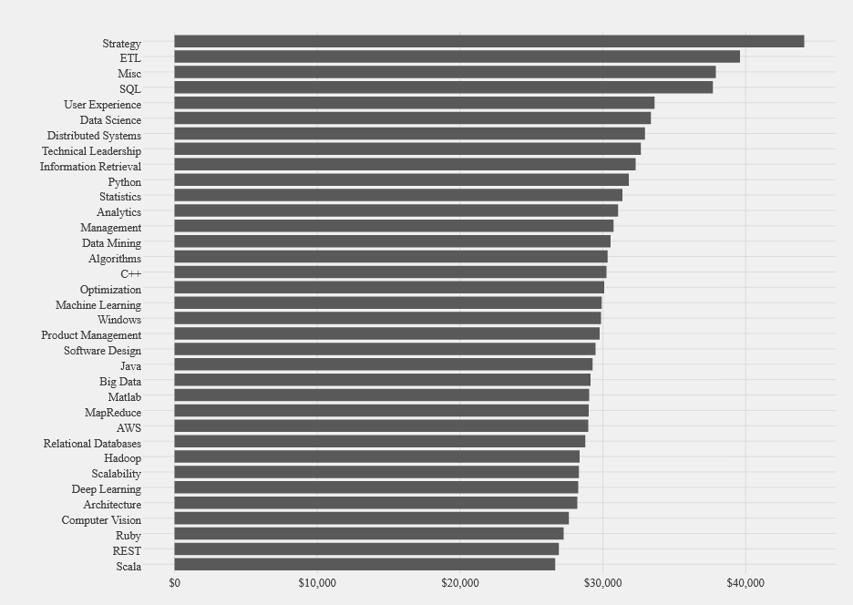

### Project - Data Science Skills

Relative Value of Skills

Using ANOVA

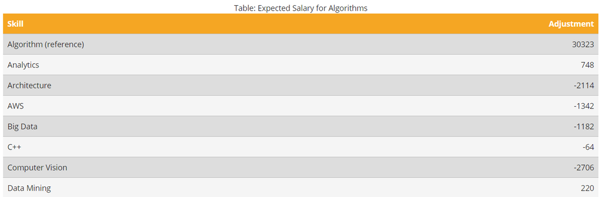

### Project - Data Science Skills

Salary weight composition

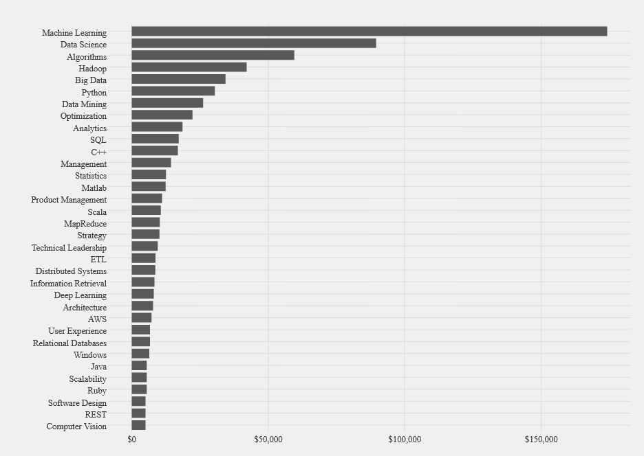

### Project - Data Science Skills

[figure not shown]

### Project - Data Science Skills

Big Challenges

- Trust was observed as a critical factor for effective communication in the team.
- Having a clear vision for the team.
- Creating team spirit and team goals.
- Prioritizing the tasks.

### Project - Data Science Skills

Communications Management

- Face-to-face communication was beneficial.
- Logging what, who and how and frequency.
- Logging origination, nuances.
- Recognizing team members accomplishments.

### Project - Data Science Skills

Communication Tools

- **Slack** and **What's App**: Social media tool, to communicate with team members.
- **Join Me**: For voice calls and idea presentation.
- **Github**: Code sharing.
- **R Studio**: Primary development tool.
- **MySQL**: RDBMS used to store data in normalized format.
- **Google Spreadsheets**: Monitoring and managing tasks.

### Project - Data Science Skills

Output

- Remotely, comparable to what we would have got working locally.
- Our team was smart.
- Could think for themselves.
- Innovative and well educated in their tasks.

### Project - Data Science Skills

Conclusions

- Project: Management Skills
- Virtual Teams versus Face-to-Face Teams.
- Working with geographically distributed professionals.
- Collaborate on a variety of workplace tasks.
- Effectiveness of information exchange.
- Creating trust and Keeping motivated.

### Team

- Duubar Villalobos: Team leader, coordinating entire team from task identification to delegation.
- Tom Detzel: Dataset Analyst, major in role in identifying the dataset. Web Scrapping and harvesting raw data.
- Pavan Akula: Data modeler, MySQL database design.
- Kyle Glide: Data wrangler, Tidying and Formatting data to store data into MySQL DB.
- Ambra Barboni-Alexander: Data wrangler, Tidying and Formatting data to store data into MySQL DB.
- Raghunathan Ramnath: Data wrangler, Tidying and Formatting data to store data into MySQL DB.
- Dilip Ganesan: Data wrangler, Pattern recognition and producing raw dataset.

### Project - Data Science Skills

[figure not shown]